# Project Python Foundations: FoodHub Data Analysis

**Marks: 60**

### Context

The number of restaurants in New York is increasing day by day. Lots of students and busy professionals rely on those restaurants due to their hectic lifestyles. Online food delivery service is a great option for them. It provides them with good food from their favorite restaurants. A food aggregator company FoodHub offers access to multiple restaurants through a single smartphone app.

The app allows the restaurants to receive a direct online order from a customer. The app assigns a delivery person from the company to pick up the order after it is confirmed by the restaurant. The delivery person then uses the map to reach the restaurant and waits for the food package. Once the food package is handed over to the delivery person, he/she confirms the pick-up in the app and travels to the customer's location to deliver the food. The delivery person confirms the drop-off in the app after delivering the food package to the customer. The customer can rate the order in the app. The food aggregator earns money by collecting a fixed margin of the delivery order from the restaurants.

### Objective

The food aggregator company has stored the data of the different orders made by the registered customers in their online portal. They want to analyze the data to get a fair idea about the demand of different restaurants which will help them in enhancing their customer experience. Suppose you are hired as a Data Scientist in this company and the Data Science team has shared some of the key questions that need to be answered. Perform the data analysis to find answers to these questions that will help the company to improve the business.

### Data Description

The data contains the different data related to a food order. The detailed data dictionary is given below.

### Data Dictionary

- order_id: Unique ID of the order
- customer_id: ID of the customer who ordered the food
- restaurant_name: Name of the restaurant
- cuisine_type: Cuisine ordered by the customer
- cost: Cost of the order
- day_of_the_week: Indicates whether the order is placed on a weekday or weekend (The weekday is from Monday to Friday and the weekend is Saturday and Sunday)
- rating: Rating given by the customer out of 5
- food_preparation_time: Time (in minutes) taken by the restaurant to prepare the food. This is calculated by taking the difference between the timestamps of the restaurant's order confirmation and the delivery person's pick-up confirmation.
- delivery_time: Time (in minutes) taken by the delivery person to deliver the food package. This is calculated by taking the difference between the timestamps of the delivery person's pick-up confirmation and drop-off information

### Let us start by importing the required libraries

```python
# import libraries for data manipulation
import numpy as np
import pandas as pd

# import libraries for data visualization
import matplotlib.pyplot as plt
import seaborn as sns

# set decimal places to 2
pd.set_option('display.float_format', lambda x: '%.2f' % x)
```

### Understanding the structure of the data

```python
from google.colab import drive
drive.mount('/content/drive')
```

```python
# read the data
df = pd.read_csv('/content/drive/My Drive/Data Science/GL Projects/foodhub_order.csv')

# returns the first 5 rows
df.head()
```

|  | order_id | customer_id | restaurant_name | cuisine_type | cost_of_the_order | day_of_the_week | rating | food_preparation_time | delivery_time |
| --- | --- | --- | --- | --- | --- | --- | --- | --- | --- |
| 0 | 1477147 | 337525 | Hangawi | Korean | 30.75 | Weekend | Not given | 25 | 20 |
| 1 | 1477685 | 358141 | Blue Ribbon Sushi Izakaya | Japanese | 12.08 | Weekend | Not given | 25 | 23 |
| 2 | 1477070 | 66393 | Cafe Habana | Mexican | 12.23 | Weekday | 5 | 23 | 28 |
| 3 | 1477334 | 106968 | Blue Ribbon Fried Chicken | American | 29.20 | Weekend | 3 | 25 | 15 |
| 4 | 1478249 | 76942 | Dirty Bird to Go | American | 11.59 | Weekday | 4 | 25 | 24 |

#### Observations:

The DataFrame has 9 columns as mentioned in the Data Dictionary. Data in each row corresponds to the order placed by a customer.

### **Question 1:** How many rows and columns are present in the data? [0.5 mark]

```python
df.shape
```

```
(1898, 9)
```

#### Observations:

There are 1898 rows and 9 columns.

### **Question 2:** What are the datatypes of the different columns in the dataset? (The info() function can be used) [0.5 mark]

```python
# Use info() to print a concise summary of the DataFrame
df.info()
```

```
<class 'pandas.core.frame.DataFrame'>
RangeIndex: 1898 entries, 0 to 1897
Data columns (total 9 columns):
 #   Column                 Non-Null Count  Dtype
---  ------                 --------------  -----
 0   order_id               1898 non-null   int64
 1   customer_id            1898 non-null   int64
 2   restaurant_name        1898 non-null   object
 3   cuisine_type           1898 non-null   object
 4   cost_of_the_order      1898 non-null   float64
 5   day_of_the_week        1898 non-null   object
 6   rating                 1898 non-null   object
 7   food_preparation_time  1898 non-null   int64
 8   delivery_time          1898 non-null   int64
dtypes: float64(1), int64(4), object(4)
memory usage: 133.6+ KB
```

#### Observations:

Columns of int64 (integer) type include: order_id, customer_id, food_preparation_time and delivery_time.  
Columns of object (string) type include: restaurant_name, cuisine_type, day_of_the_week and rating.  
cost_of_the_order column is type float64.

### **Question 3:** Are there any missing values in the data? If yes, treat them using an appropriate method. [1 mark]

```python
df.isnull().sum()
```

```
order_id                 0
customer_id              0
restaurant_name          0
cuisine_type             0
cost_of_the_order        0
day_of_the_week          0
rating                   0
food_preparation_time    0
delivery_time            0
dtype: int64
```

#### Observations:

There are no missing values.

### **Question 4:** Check the statistical summary of the data. What is the minimum, average, and maximum time it takes for food to be prepared once an order is placed? [2 marks]

```python
df.describe().T
```

|  | count | mean | std | min | 25% | 50% | 75% | max |
| --- | --- | --- | --- | --- | --- | --- | --- | --- |
| order_id | 1898.00 | 1477495.50 | 548.05 | 1476547.00 | 1477021.25 | 1477495.50 | 1477969.75 | 1478444.00 |
| customer_id | 1898.00 | 171168.48 | 113698.14 | 1311.00 | 77787.75 | 128600.00 | 270525.00 | 405334.00 |
| cost_of_the_order | 1898.00 | 16.50 | 7.48 | 4.47 | 12.08 | 14.14 | 22.30 | 35.41 |
| food_preparation_time | 1898.00 | 27.37 | 4.63 | 20.00 | 23.00 | 27.00 | 31.00 | 35.00 |
| delivery_time | 1898.00 | 24.16 | 4.97 | 15.00 | 20.00 | 25.00 | 28.00 | 33.00 |

#### Observations:

Minimum food preparation time = 20 minutes  
Average food preparation time = 27 minutes  
Maximum food preparation time = 35 minutes

### **Question 5:** How many orders are not rated? [1 mark]

```python
df[df['rating']=='Not given']['rating'].count()
```

```
736
```

#### Observations:

736 orders are not rated.

### Exploratory Data Analysis (EDA)

### **Question 6:** Explore all the variables and provide observations on their distributions. (Generally, histograms, boxplots, countplots, etc. are used for univariate exploration.) [9 marks]

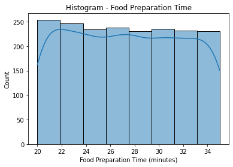

```python
plt.title("Histogram - Food Preparation Time")
plt.xlabel("Food Preparation Time (minutes)")
sns.histplot(data=df, x='food_preparation_time', bins=8, kde=True);
```

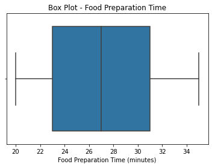

```python
plt.title("Box Plot - Food Preparation Time")
sns.boxplot(data=df, x='food_preparation_time')
plt.xlabel("Food Preparation Time (minutes)");
```

Observations: Food preparation time follows a relatively uniform distribution pattern - frequencies are similar across the bins. The median food preparation time is 27 minutes. Food preparation times range from 20 to 35 minutes. There are no outliers.

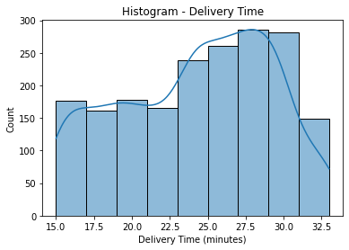

```python
plt.title("Histogram - Delivery Time")
plt.xlabel("Delivery Time (minutes)")
sns.histplot(data=df, x='delivery_time', kde=True, bins=9);
```

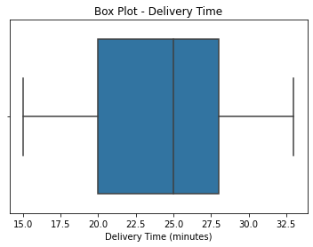

```python
plt.title("Box Plot - Delivery Time")
sns.boxplot(data=df, x='delivery_time')
plt.xlabel("Delivery Time (minutes)");
```

Observations: Delivery time follows an asymmetric distribution pattern which is somewhat skewed left. The median delivery time is 25 minutes. Delivery times range from 15 to 33 minutes. There are no outliers.

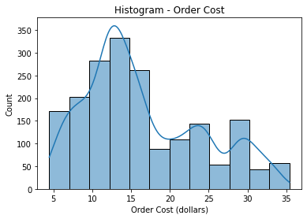

```python
plt.title("Histogram - Order Cost")
plt.xlabel("Order Cost (dollars)")
sns.histplot(data=df, x='cost_of_the_order', kde=True, bins=12);
```

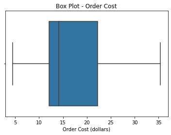

```python
plt.title("Box Plot - Order Cost")
sns.boxplot(data=df, x='cost_of_the_order')
plt.xlabel("Order Cost (dollars)");
```

Observations: Order cost follows an asymmetric distribution pattern which is skewed right. The median cost is \$14.14. Order costs range from \$4.47 to $35.41. There are no outliers.

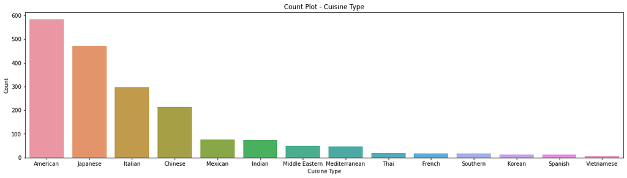

```python
plt.figure(figsize=(20,5))
plt.title("Count Plot - Cuisine Type")
sns.countplot(data=df, x='cuisine_type', order = df['cuisine_type'].value_counts().index)
plt.xlabel("Cuisine Type")
plt.ylabel("Count");
```

Observations: The top 3 most commonly ordered cuisine types are American, Japanese and Italian. The least common are Vietnamese, Spanish and Korean.

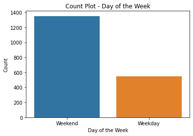

```python
plt.title("Count Plot - Day of the Week")
sns.countplot(data=df, x='day_of_the_week')
plt.xlabel("Day of the Week")
plt.ylabel("Count");
```

Observations: More orders are placed on the weekend compared to weekdays.

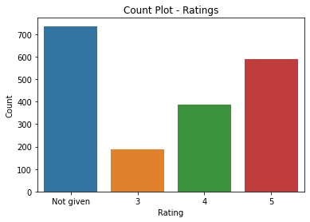

```python
plt.title("Count Plot - Ratings")
sns.countplot(data=df, x='rating', order=['Not given','3','4','5'])
plt.xlabel("Rating")
plt.ylabel("Count");
```

Observations: The most common rating is 5. It is also common for no rating to be given.

### **Question 7**: Which are the top 5 restaurants in terms of the number of orders received? [1 mark]

```python
df['restaurant_name'].value_counts().head()
```

```
Shake Shack                  219
The Meatball Shop            132
Blue Ribbon Sushi            119
Blue Ribbon Fried Chicken     96
Parm                          68
Name: restaurant_name, dtype: int64
```

#### Observations:

The top 5 restaurants in terms of number of orders received are:

1. Shake Shack
2. The Meatball Shop
3. Blue Ribbon Sushi
4. Blue Ribbon Fried Chicken
5. Parm

### **Question 8**: Which is the most popular cuisine on weekends? [1 mark]

```python
# Checking value_counts of cuisine_type for rows where day_of_the_week is 'Weekend'.

df[df['day_of_the_week']=='Weekend']['cuisine_type'].value_counts().head(1)
```

```
American    415
Name: cuisine_type, dtype: int64
```

#### Observations:

The most popular cuisine on weekends is American.

### **Question 9**: What percentage of the orders cost more than 20 dollars? [2 marks]

```python
# Index based on condition to select rows (orders) where cost is greater than 20 dollars
# Count the number of rows (orders) where cost is greater than 20 dollars with .shape attribute
# Divide by the total number of rows (orders) in the original DataFrame and multiply by 100 to get percent

df[df['cost_of_the_order']>20].shape[0]/df.shape[0]*100
```

```
29.24130663856691
```

#### Observations:

29.2% of the orders cost more than 20 dollars.

### **Question 10**: What is the mean order delivery time? [1 mark]

```python
# Use .mean() method to find the mean of a column/Series

df['delivery_time'].mean()
```

```
24.161749209694417
```

#### Observations:

The mean order delivery time is 24 minutes.

### **Question 11:** The company has decided to give 20% discount vouchers to the top 3 most frequent customers. Find the IDs of these customers and the number of orders they placed. [1 mark]

```python
# Use value_counts method to check the number of orders placed by each unique customer ID in order from greatest to least.

df['customer_id'].value_counts().head(3)
```

```
52832    13
47440    10
83287     9
Name: customer_id, dtype: int64
```

#### Observations:

Top customer was ID #52832 who placed 13 orders.  
2nd most frequent customer was ID #47440 who placed 10 orders.  
3rd most frequent customer was ID #83287 who placed 9 orders.

### **Question 12**: Perform a multivariate analysis to explore relationships between the important variables in the dataset. (It is a good idea to explore relations between numerical variables as well as relations between numerical and categorical variables) [10 marks]

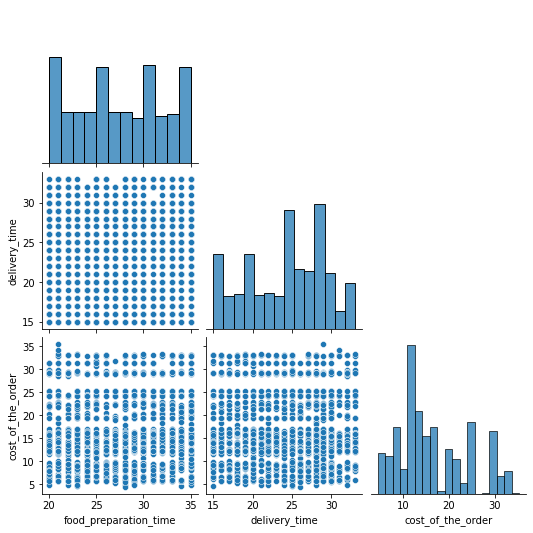

```python
# Check pairplot to look for relationships between numerical variables.

sns.pairplot(data=df[['food_preparation_time','delivery_time','cost_of_the_order']], corner=True);
```

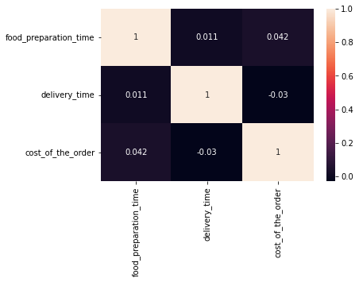

```python
# Calculate and visualize correlation coefficient for numerical variables using heatmap and .corr method.

sns.heatmap(data=df[['food_preparation_time','delivery_time','cost_of_the_order']].corr(), annot=True);
```

Observations: There is no significant correlation between delivery time, food preparation time or cost of the order.

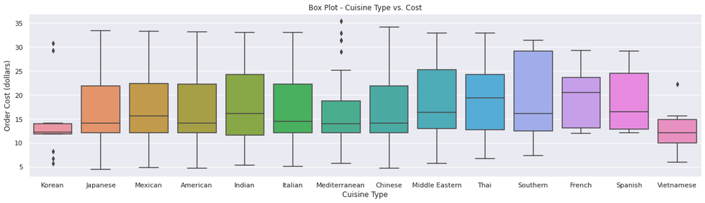

```python
# Use boxplot to compare cost distribution within different cuisine type categories.

plt.figure(figsize=(20,5))
sns.set(style='darkgrid')
plt.title("Box Plot - Cuisine Type vs. Cost")
sns.boxplot(data=df, x='cuisine_type',y='cost_of_the_order')
plt.xlabel("Cuisine Type")
plt.ylabel("Order Cost (dollars)");
```

Observations: French cuisine had the highest median cost. Vietnamese and Korean cuisine had the lowest median cost.

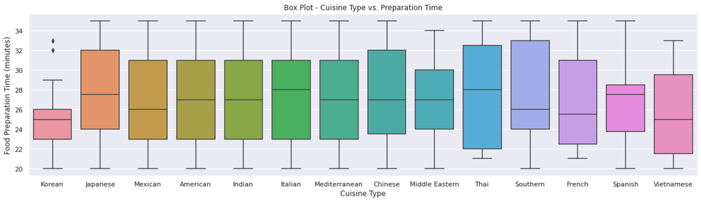

```python
# Use boxplot to compare preparation time distribution within different cuisine type categories.

plt.figure(figsize=(20,5))
sns.set(style='darkgrid')
plt.title("Box Plot - Cuisine Type vs. Preparation Time")
sns.boxplot(data=df, x='cuisine_type',y='food_preparation_time')
plt.xlabel("Cuisine Type")
plt.ylabel("Food Preparation Time (minutes)");
```

Thai & Italian cuisine had the highest median food preparation time. Vietnamese and Korean cuisine had the lowest median food preparation time (this could explain why they also had the lowest median cost).

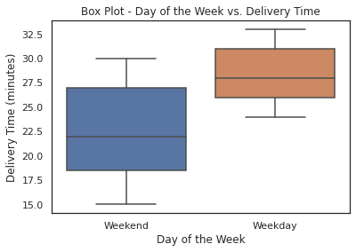

```python
sns.set(style='white')
plt.title("Box Plot - Day of the Week vs. Delivery Time")
sns.boxplot(data=df, x='day_of_the_week', y='delivery_time')
plt.xlabel("Day of the Week")
plt.ylabel("Delivery Time (minutes)");
```

Observations: Median delivery time was higher on weekdays compared to weekends.

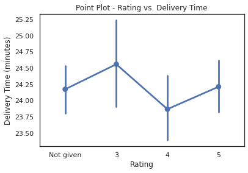

```python
plt.title("Point Plot - Rating vs. Delivery Time")
sns.pointplot(data=df, x='rating', y='delivery_time', order=['Not given','3','4','5'])
plt.xlabel("Rating")
plt.ylabel("Delivery Time (minutes)");
```

Observations: Orders with lowest rating (3) had a higher delivery time on average.

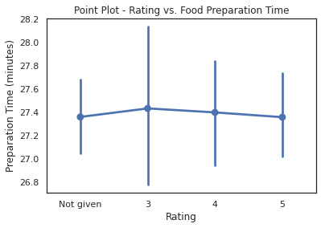

```python
plt.title("Point Plot - Rating vs. Food Preparation Time")
sns.pointplot(data=df, x='rating', y='food_preparation_time', order=['Not given','3','4','5'])
plt.xlabel("Rating")
plt.ylabel("Preparation Time (minutes)");
```

Observation: Average food preparation time was similar across different ratings.

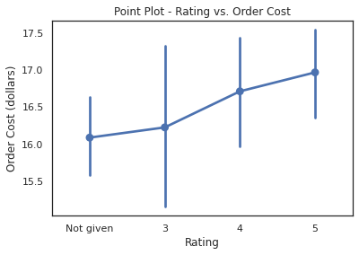

```python
plt.title("Point Plot - Rating vs. Order Cost")
sns.pointplot(data=df, x='rating', y='cost_of_the_order', order=['Not given','3','4','5'])
plt.xlabel("Rating")
plt.ylabel("Order Cost (dollars)");
```

Observations: Orders with a higher rating tended to have a higher cost on average.

### **Question 13:** The company wants to provide a promotional offer in the advertisement of the restaurants. The condition to get the offer is that the restaurants must have a rating count of more than 50 and the average rating should be greater than 4. Find the restaurants fulfilling the criteria to get the promotional offer. [3 marks]

```python
# Create a new DataFrame excluding rows where 'rating' was 'Not given'.

df_ratings = df[df['rating']!='Not given'].copy()
```

```python
# Change data type of 'rating' column to numeric type in order to perform arithmetic (mean) calculation.

df_ratings['rating'] = df_ratings['rating'].astype(float)
```

```python
# Use groupby method to create a new DataFrame with restaurants' rating mean and rating count.

df_ratings_agg = df_ratings.groupby('restaurant_name')['rating'].agg(['mean','count']).reset_index()
df_ratings_agg
```

|  | restaurant_name | mean | count |
| --- | --- | --- | --- |
| 0 | 'wichcraft | 5.00 | 1 |
| 1 | 12 Chairs | 4.50 | 2 |
| 2 | 5 Napkin Burger | 4.00 | 2 |
| 3 | 67 Burger | 5.00 | 1 |
| 4 | Amma | 4.50 | 2 |
| ... | ... | ... | ... |
| 151 | Zero Otto Nove | 4.00 | 1 |
| 152 | brgr | 3.00 | 1 |
| 153 | da Umberto | 5.00 | 1 |
| 154 | ilili Restaurant | 4.15 | 13 |
| 155 | indikitch | 4.50 | 2 |

156 rows × 3 columns

```python
# Use logical indexing to display a list of the restaurants with mean rating above 4 and rating count more than 50.

df_ratings_agg[(df_ratings_agg['mean']>4)&(df_ratings_agg['count']>50)]['restaurant_name'].tolist()
```

```
['Blue Ribbon Fried Chicken',
 'Blue Ribbon Sushi',
 'Shake Shack',
 'The Meatball Shop']
```

#### Observations:

The following restaurants have a rating count of more than 50 and average rating greater than 4:

- Blue Ribbon Fried Chicken
- Blue Ribbon Sushi
- Shake Shack
- The Meatball Shop

### **Question 14:** The company charges the restaurant 25% on the orders having cost greater than 20 dollars and 15% on the orders having cost greater than 5 dollars. Find the net revenue generated by the company across all orders. [3 marks]

```python
# Find the sum of 'cost_of_the_order' where cost is greater than 20 and multiply by 0.25 to get 25%.
# Find the sum of 'cost_of_the_order' where cost is greater than 5 and less than or equal to 20. Mutiply by 0.15 to get 15%.
# Add the two together to get net revenue across all orders.

df[df['cost_of_the_order']>20]['cost_of_the_order'].sum()*.25 + df[(df['cost_of_the_order']>5)&(df['cost_of_the_order']<=20)]['cost_of_the_order'].sum()*.15
```

```
6166.303
```

#### Observations: The net revenue is $6166.30

### **Question 15:** The company wants to analyze the total time required to deliver the food. What percentage of orders take more than 60 minutes to get delivered from the time the order is placed? (The food has to be prepared and then delivered.) [2 marks]

```python
# Create a new column called 'total_time' which is the sum of food_preparation_time plus delivery_time.
# Use conditional indexing with .shape method to count the number of rows where total_time is greater than 60. Divide by original number of rows & multiply by 100 to get percent.

df['total_time'] = df['food_preparation_time'] + df['delivery_time']
df[df['total_time']>60].shape[0]/df.shape[0]*100
```

```
10.537407797681771
```

#### Observations:

10.5% of orders take more than 60 minutes to get delivered from the time the order is placed.

### **Question 16:** The company wants to analyze the delivery time of the orders on weekdays and weekends. How does the mean delivery time vary during weekdays and weekends? [2 marks]

```python
# Find the difference between the mean delivery time on weekdays vs. weekends using logical indexing.

df[df['day_of_the_week']=='Weekday']['delivery_time'].mean()-df[df['day_of_the_week']=='Weekend']['delivery_time'].mean()
```

```
5.870014357297798
```

#### Observations:

The mean delivery time is about 6 minutes higher on weekdays compared to weekends.

### Conclusion and Recommendations

### **Question 17:** What are your conclusions from the analysis? What recommendations would you like to share to help improve the business? (You can use cuisine type and feedback ratings to drive your business recommendations.) [6 marks]

### Conclusions:

- The top 3 most commonly ordered cuisine types are American, Japanese and Italian. The least common are Vietnamese, Spanish and Korean.
- Vietnamese and Korean cuisine had the lowest median cost and lowest median food preparation time.
- More orders are placed on the weekend compared to weekdays.
- Median delivery time was higher on weekdays vs. weekends.
- Orders with lowest rating (3) had a higher delivery time on average.
- Orders with a higher rating tended to have a higher cost on average.
- Nearly 40% of orders were not rated.